# Stat159 Project 2: Predictive Modeling Process

11/1/2016

## Introduction

- In this project, we explore the difference between various muitiple regression methods and conclude on what approach should be used in order to fit our data better
- In our analysis, we compare the fit of models generated by 5 different regression methods
  - Ordinary Least Squares
  - Ridge regression
  - Lasso regression
  - Principal Components regression
  - Partial Least Squares regression
- We perform 10-fold cross validation in the model construction process and select the model with minimum cross-validation errors in terms of the running parameter

## Data

- The data we used in this project is provided by the textbook **An Introduction to Statistical Learning**
- The data set can be downloaded from http://www-bcf.usc.edu/~gareth/ISL/Credit.csv
- Pre-modeling Data Processing:
  - Dummy out categorical variables
  - Mean centering and standardizing
- Divide the data into training set and test set:
  - Randomly select 300 entries to be the train set
  - The remaining 100 entries is the test set

## Methods

### Least Squares Method

- OLS coefficients are set as benchmark to compare the coefficients of the other four regression methods
- OLS estimators are obtained by minimizing the sum of squares \(RSS = \sum_{i=1}^n(y_i - \beta_0 - \sum_{j=1}^p(\beta_{j}x_{ij}))^2\) where \(\beta_0, ..., \beta_p\) are our coefficient estimates
- OLS is the most common regression method, and it works the best when we have homoskedastic and uncorrelated errors within the data

## Methods

### Ridge Regression

- Instead of minimizing RSS, Ridge regression minimizes \(RSS + \lambda \sum bj^2\)
- \(\lambda\) is called a tuning parameter and it controls how much RSS and shrinkage panelty affects the regression model
- One of the main feature of ridge regression is the bias-variance trade-off

## Methods

### Lasso Regression

- The major difference between Lasso and Ridge is that Lasso method aims to minimize \(RSS\) + \(\lambda \sum |{\beta_j}|\)
- Ridge regression will always generate a model with all predictors since it doesn't involve a process of variable reduction
- Lasso improves by allowing some of the coefficient estimates to be exactly 0 if the tunning parameter is sufficiently large
- In general, lasso is expected to outperform ridge when we have a small amount of predictors having significant coefficients, and the rest close to 0

## Methods

### Principal Components Regression

- The key assumption we hold in this regression model is that the directions in which \(X_1, ..., X_p\) show the most variation are the directions that are associated with Y
- PCR performs the best when the first few pricipal components are sufficient to capture most of the variation in the predictors and their relationship with the response

## Methods

### Partial Least Squares Regression

- In comparison to PCR regression, which uses unsupervised method to dentify the principal components, partial least squares method takes the advantage of a supervised learning process
- It uses the response variable Y to identify new vectors that are not only similar to existing regressors, but also select the ones that are related to the response
- PLS approach attempts to find directions that help explain both the response and the predictors

## Model Building Process

- Use 10-fold cross validation in building each regression model
- Use the train set to fit the model
- Calculate MSE in the test set
- Fit the model we select to the entire data set

## Results

### OLS Regression Coefficient Estimates

|  | Estimate | Std. Error | t value | Pr(>\|t\|) |
| --- | --- | --- | --- | --- |
| (Intercept) | -0.00124 | 0.01226 | -0.10155 | 0.91919 |
| Income | -0.59637 | 0.02016 | -29.58094 | 0.00000 |
| Limit | 0.95449 | 0.18629 | 5.12379 | 0.00000 |
| Rating | 0.38309 | 0.18728 | 2.04550 | 0.04171 |
| Cards | 0.05100 | 0.01436 | 3.55029 | 0.00045 |
| Age | -0.02592 | 0.01276 | -2.03223 | 0.04305 |
| Education | -0.01469 | 0.01242 | -1.18310 | 0.23775 |
| GenderFemale | -0.02197 | 0.01231 | -1.78433 | 0.07542 |
| StudentYes | 0.27607 | 0.01273 | 21.68359 | 0.00000 |
| MarriedYes | -0.01706 | 0.01266 | -1.34767 | 0.17882 |
| EthnicityAsian | 0.00548 | 0.01512 | 0.36270 | 0.71710 |
| EthnicityCaucasian | -0.00474 | 0.01494 | -0.31721 | 0.75131 |

## Results

### OLS Regression Analysis

- Some coefficients come with a big p-value, which means that they are not statistically significant
- We can conclude that the constant term, Education, Gender, Marital Status and Ethinicity don't belong to this regression
- Among the statistically significant regressors, some has very small coefficients, so the main factors influencing Balance are Income, Limit and Rating

## Results

### Ridge Regression Coefficient Estimates

|  | Estimate |
| --- | --- |
| (Intercept) | 0.00000 |
| Income | -0.56871 |
| Limit | 0.71866 |
| Rating | 0.59306 |
| Cards | 0.04425 |
| Age | -0.02538 |
| Education | -0.00588 |
| GenderFemale | -0.01068 |
| StudentYes | 0.27318 |
| MarriedYes | -0.01103 |
| EthnicityAsian | 0.01638 |
| EthnicityCaucasian | 0.01101 |

## Results

### Lasso Regression Coefficient Estimates

|  | Estimate |
| --- | --- |
| (Intercept) | 0.00000 |
| Income | -0.55166 |
| Limit | 0.92505 |
| Rating | 0.36787 |
| Cards | 0.04500 |
| Age | -0.01666 |
| Education | 0.00000 |
| GenderFemale | 0.00000 |
| StudentYes | 0.26681 |
| MarriedYes | 0.00000 |
| EthnicityAsian | 0.00000 |
| EthnicityCaucasian | 0.00000 |

## Results

### Lasso Regression Analysis

- The \(\lambda\) we found that results in the smallest validation error is \(\lambda\) = 0.01
- We can see that a significant improvement is that we have a number of regressors with a coefficient of 0 which makes the intepretation much easier

## Results

### PCR Coefficient Estimates

|  | Estimate |
| --- | --- |
| Income | -0.59887 |
| Limit | 0.67141 |
| Rating | 0.67064 |
| Cards | 0.04043 |
| Age | -0.02327 |
| Education | -0.00600 |
| GenderFemale | -0.01165 |
| StudentYes | 0.27636 |
| MarriedYes | -0.01116 |
| EthnicityAsian | 0.01741 |
| EthnicityCaucasian | 0.01119 |

## Results

### PLSR Coefficient Estimates

|  | Estimate |
| --- | --- |
| Income | -0.59801 |
| Limit | 0.67458 |
| Rating | 0.66699 |
| Cards | 0.04808 |
| Age | -0.02592 |
| Education | -0.00908 |
| GenderFemale | -0.01671 |
| StudentYes | 0.27394 |
| MarriedYes | -0.00800 |
| EthnicityAsian | 0.02257 |
| EthnicityCaucasian | 0.01101 |

## Comparing the Coefficient Estimates for 5 Regression Models

|  | ols | ridge | lasso | pcr | plsr |
| --- | --- | --- | --- | --- | --- |
| (Intercept) | 0.00000 | 0.00000 | 0.00000 | 0.00000 | 0.00000 |
| Income | -0.59817 | -0.56871 | -0.55166 | -0.59887 | -0.59801 |
| Limit | 0.95844 | 0.71866 | 0.92505 | 0.67141 | 0.67458 |
| Rating | 0.38248 | 0.59306 | 0.36787 | 0.67064 | 0.66699 |
| Cards | 0.05286 | 0.04425 | 0.04500 | 0.04043 | 0.04808 |
| Age | -0.02303 | -0.02538 | -0.01666 | -0.02327 | -0.02592 |
| Education | -0.00747 | -0.00588 | 0.00000 | -0.00600 | -0.00908 |
| GenderFemale | -0.01159 | -0.01068 | 0.00000 | -0.01165 | -0.01671 |
| StudentYes | 0.27815 | 0.27318 | 0.26681 | 0.27636 | 0.27394 |
| MarriedYes | -0.00905 | -0.01103 | 0.00000 | -0.01116 | -0.00800 |
| EthnicityAsian | 0.01595 | 0.01638 | 0.00000 | 0.01741 | 0.02257 |
| EthnicityCaucasian | 0.01101 | 0.01101 | 0.00000 | 0.01119 | 0.01101 |

## Comparing the MSE of 5 Regression Models

|  | MSE |
| --- | --- |
| ols | 0.05179 |
| ridge | 0.05259 |
| lasso | 0.05154 |
| pcr | 0.05200 |
| plsr | 0.05192 |

## Trend Lines of Coefficient Estimates of 5 Regression Models

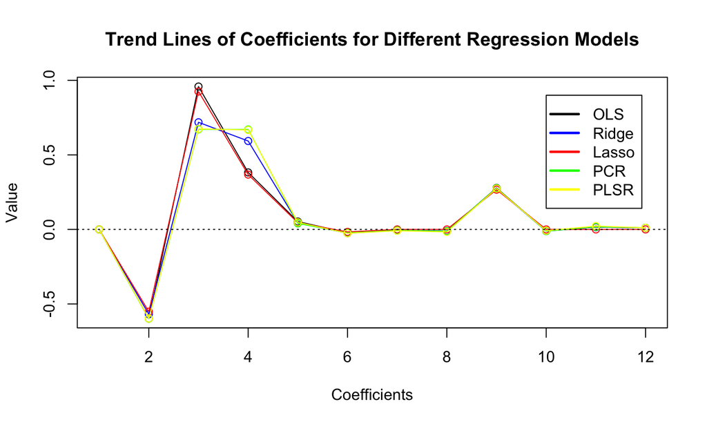